# Homework 5

Beau Britain, David Duffrin, Noah Johnson, Roger Filmyer, Stephanie Rivera

11/22/2017

# Guidelines

- This is a group project. You may work in groups with up to 6 people. You only need to turn in one homework assignment for each group, but make sure that everyone’s name is listed on the assignment.
- Also, even if you don’t write the code for every part of the assignment, you should practice the skills in each section.
- This assignment focuses on simulating data that violates various assumptions of the linear regression model.
- Some sample code has been included, but you will need to try many different starting values for the parameters, sample size, and distributional assumptions. The included code is just to give you a starting point; it should not be considered sufficient to answer all the questions in each part. (And you are welcome to ignore the sample code and use your own)

# Questions

## Question 1 (Non-linear Relationships)

````
#a. Simulate data for a variety of different non-linear relationships (e.g. polynomial, exponential, sinusoidal).


```r
polynomial <- function(x) {
  return (x^2)
}
exponential <- function(x) {
  return (exp(x))
}
sinusoidal <- function(x) {
  return (sin(x))
}
Fs <- c(polynomial, exponential, sinusoidal)
```

#b. Try simulations with a small sample size (e.g. 20), a medium sample size (e.g. n= 100), and a large sample size (e.g. n = 5000).
#c. For each simulation,
    #i. Predict y-hat at several different locations using a confidence interval.
    #ii.    Predict the beta coefficients for a linear model using a confidence interval.
    #iii. Find the MSE (to estimate sigma^2)
    #iv. Test to see whether the beta(s) are significant


```r
Ns <- c(20,100,5000) # small, medium, large
x_lim.lower <- -10
x_lim.upper <- 10
noise.mean <- 0
noise.sds <- c(10, 500, 1.5)

sample_x.list <- c()
sample_y.list <- c()

y_hat.locations <- data.frame(sample_x = base::sample(x_lim.lower:x_lim.upper, size = 4, replace = FALSE)) # Use same variable name as predictor in lm

for (i in 1:length(Fs)) {
  f <- Fs[[i]]
  noise.sd <- noise.sds[i]
  print("")
````

[output cut: 411 more lines]

````
  print(sprintf("Slope IS significant at the %.3f level", alpha))
} else {
  print(sprintf("Slope IS NOT significant at the %.3f level", alpha))
}
```

```
## [1] "Slope IS significant at the 0.050 level"
```

    I can make educated guesses based on the significance tests of the slope.

    #iii. Based on the diagnostics, predict whether the problem areas you mentioned in part d will be affected or not. (Note: You are not predicting whether the assumptions are violated -- just whether they are violated to such an extent that your ability to use the model is compromised)

    The linear model is not compromised in any way no matter the underlying data, however it may not be a useful fit.
````

**Aside:** Many of the issues you end up facing with a nonlinear relationship can also be seen if an important predictor is excluded from the model. If you have extra time, feel free to play with this issue as well (optional).

## Question 2 (Non-normal errors)

### A

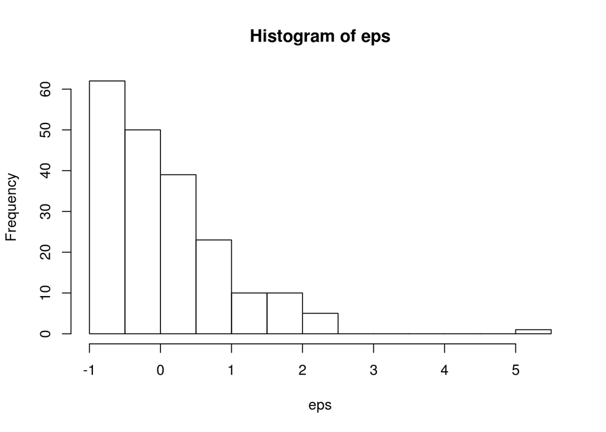

```r
set.seed(99)
# gamma
n <- 200
b0 <- 10
b1 <- 2
eps_alpha <- 2
eps_beta <- 1/4

x <- runif(n, 0, 10)
eps <- (rgamma(n, eps_alpha, 1/eps_beta) - eps_alpha * eps_beta) * 2
y <- b0 - b1 * x + eps

hist(eps)
```

```r
var(eps)
```

```
## [1] 0.7502614
```

```r
mean(eps)
```

```
## [1] 0.06013122
```

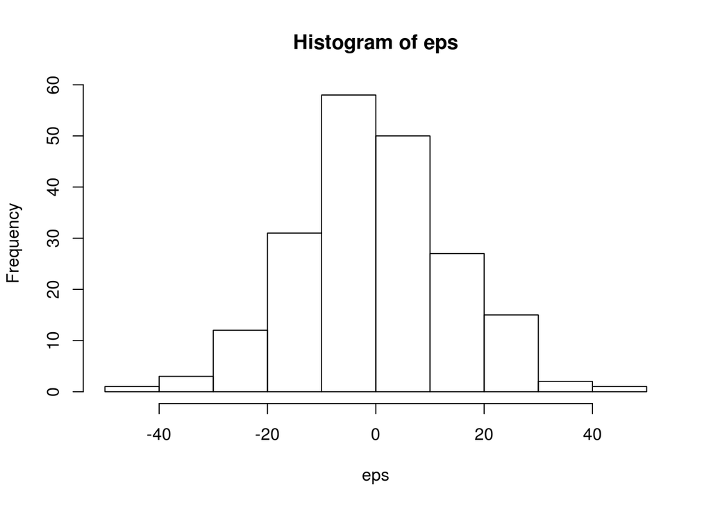

```r
# poisson
n <- 200
lambda <- 50

x <- runif(n, 0, 10)
eps <- (rpois(n, lambda) - lambda) * 2
y <- b0 - b1 * x + eps

hist(eps)
```

```r
var(eps)
```

```
## [1] 201.8869
```

```r
mean(eps)
```

```
## [1] 0.55
```

### B

```r
# gamma
generateGamma <- function (n, x, b0, b1) {
  eps_alpha <- 2
  eps_beta <- 1/4
  eps <- (rgamma(n, eps_alpha, 1/eps_beta) - eps_alpha * eps_beta) * 2
  # variance is alpha * beta^2 * 2^2: 0.5
  y <- b0 + b1 * x + eps
  return(y)
}

# poisson
generatePoisson <- function (n, x, b0, b1) {
  lambda <- 50
  eps <- (rpois(n, lambda) - lambda) * 2
  # variance is lambda * 2^2: 200
  y <- b0 + b1 * x + eps
  return(y)
}

# normal
generateNormal <- function (n, x, b0, b1) {
  sd <- 1
  eps <- (rnorm(n, 0, sd)) * 2
  # variance is sd^2 * 2^2: 4
  y <- b0 + b1 * x + eps
  return(y)
}
```

```r
set.seed(99)
b0 <- 10
b1 <- 2

# 20
n <- 20
x.20 <- runif(n, 0, 10)
pois.20 <- generatePoisson(n, x.20, b0, b1)
gamma.20 <- generateGamma(n, x.20, b0, b1)


# 100
n <- 100
x.100 <- runif(n, 0, 10)
pois.100 <- generatePoisson(n, x.100, b0, b1)
gamma.100 <- generateGamma(n, x.100, b0, b1)

# 5000
n <- 5000
x.5000 <- runif(n, 0, 10)
pois.5000 <- generatePoisson(n, x.5000, b0, b1)
gamma.5000 <- generateGamma(n, x.5000, b0, b1)
```

### C

```r
set.seed(99)
probB <- function (xylist) {
  for (xy in xylist) {
    yname <- colnames(xy)[2]
    colnames(xy) <- c('x','y')
    #ii.
    model.fit <- lm(y~x, xy)
    #i.
    preds <- predict(model.fit, data.frame(x=c(1,3,5,50)), interval='confidence')
    # iii.
    predMSE <- anova(model.fit)[2,3]
    # iv.
    betas <- summary(model.fit)$coefficients[,c(1,3,4)]
    # confint for betas
    betarange <- confint(model.fit, level=0.95)
    # output
    print(yname)
    print('Predicted Betas with t-values and confidence intervals:')
    print(betas)
    print(betarange)
    print('Predicted values for x=1,3,5,50 (the expected values are 12, 16, 20, 110):')
    print(preds)
    print('MSE:')
    print(predMSE)
  }
}

print('Expected Variance of the Gamma distribution is 0.5 & Expected Variance of the Poisson distribution is 200')
```

```
## [1] "Expected Variance of the Gamma distribution is 0.5 & Expected Variance of the Poisson distribution is 200"
```

```r
print('Real B0 is 10 & B1 is 2')
```

```
## [1] "Real B0 is 10 & B1 is 2"
```

```r
xylist <- list(data.frame(x.20, pois.20), data.frame(x.20, gamma.20), data.frame(x.100, pois.100), data.frame(x.100, gamma.100), data.frame(x.5000, pois.5000), data.frame(x.5000, gamma.5000))

probB(xylist)
```

```
## [1] "pois.20"
## [1] "Predicted Betas with t-values and confidence intervals:"
##              Estimate  t value   Pr(>|t|)
## (Intercept) 12.543102 2.414686 0.02661167
## x            1.905023 1.973219 0.06402674
##                  2.5 %    97.5 %
## (Intercept)  1.6298507 23.456353
## x           -0.1232895  3.933335
## [1] "Predicted values for x=1,3,5,50 (the expected values are 12, 16, 20, 110):"
##         fit       lwr       upr
## 1  14.44812  5.238016  23.65823
## 2  18.25817 11.857817  24.65852
## 3  22.06822 16.589591  27.54684
## 4 107.79424 15.680856 199.90763
## [1] "MSE:"
## [1] 133.9169
## [1] "gamma.20"
## [1] "Predicted Betas with t-values and confidence intervals:"
##             Estimate  t value     Pr(>|t|)
## (Intercept) 9.723581 30.95773 4.600315e-17
## x           2.050276 35.12163 4.915753e-18
##                2.5 %    97.5 %
## (Intercept) 9.063698 10.383464
## x           1.927632  2.172921
## [1] "Predicted values for x=1,3,5,50 (the expected values are 12, 16, 20, 110):"
##         fit       lwr       upr
## 1  11.77386  11.21696  12.33076
## 2  15.87441  15.48740  16.26142
## 3  19.97496  19.64369  20.30623
## 4 112.23740 106.66765 117.80715
## [1] "MSE:"
## [1] 0.4896223
## [1] "pois.100"
## [1] "Predicted Betas with t-values and confidence intervals:"
##             Estimate  t value     Pr(>|t|)
## (Intercept) 8.756771 2.918402 4.363900e-03
## x           2.087696 4.139020 7.386174e-05
##                2.5 %    97.5 %
## (Intercept) 2.802305 14.711237
## x           1.086743  3.088649
```

[output cut: 41 more lines]

```
## [1] "Predicted Betas with t-values and confidence intervals:"
##             Estimate  t value Pr(>|t|)
## (Intercept) 9.994997 492.7795        0
## x           1.999861 566.6970        0
##                2.5 %    97.5 %
## (Intercept) 9.955234 10.034761
## x           1.992943  2.006779
## [1] "Predicted values for x=1,3,5,50 (the expected values are 12, 16, 20, 110):"
##         fit       lwr       upr
## 1  11.99486  11.96091  12.02881
## 2  15.99458  15.97045  16.01871
## 3  19.99430  19.97443  20.01418
## 4 109.98805 109.67594 110.30016
## [1] "MSE:"
## [1] 0.5137658
```

### E

```r
set.seed(99)

generateRandom <- function (n, x) {
  decision <- runif(1,0,1)
  print(decision)
  b0 <- 10
  b1 <- .5
  if (decision < 0.33) {
    return(generateNormal(n,x,b0,b1))
  } else if (decision < 0.66) {
    return(generatePoisson(n,x,b0,b1))
  } else {
    return(generateGamma(n,x,b0,b1))
  }
}

n <- 100
x <- runif(n, 0, 10)
y <- generateRandom(n, x)
```

```
## [1] 0.05744927
```

```r
model.fit <- lm(y~x)
summary(model.fit)$coefficients[,c(1,3,4)] # betas
```

```
##              Estimate  t value     Pr(>|t|)
## (Intercept) 9.9800496 23.91759 1.070534e-42
## x           0.5826698  7.91565 3.837602e-12
```

```r
confint(model.fit) # betas confidence interval
```

```
##                 2.5 %     97.5 %
## (Intercept) 9.1519945 10.8081047
## x           0.4365934  0.7287461
```

```r
anova(model.fit)[2,3] # MSE
```

```
## [1] 4.548976
```

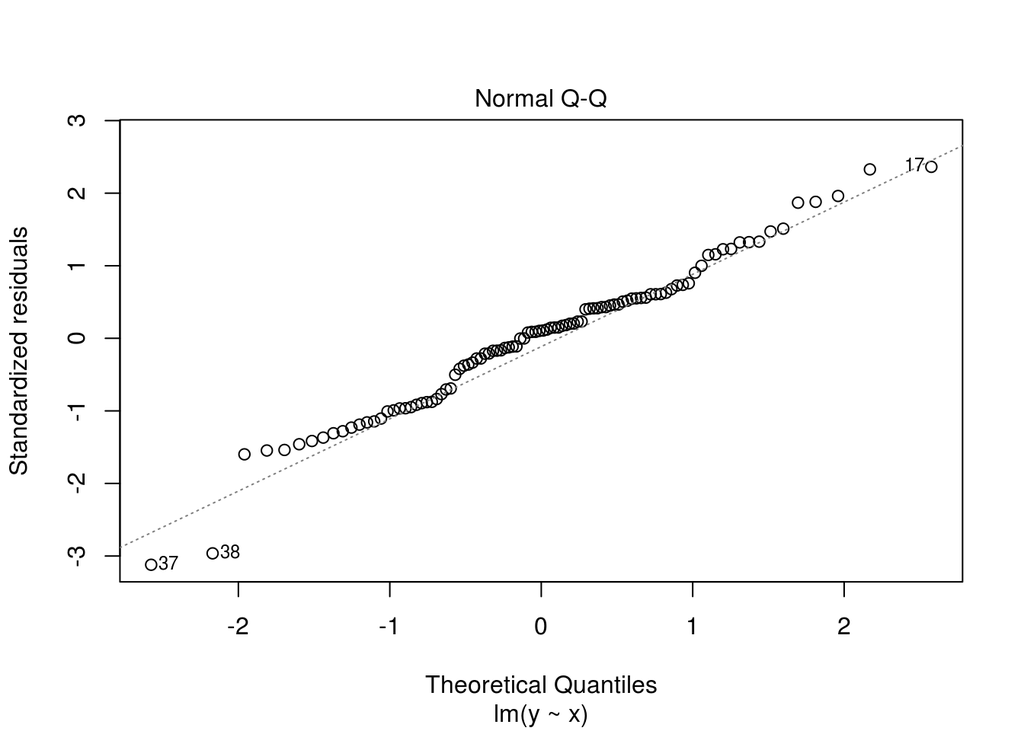

```r
plot(model.fit, which=2) # plot
```

- The coefficients are almost exact.
- MSE is very low - matches the variance of the generating function for normal eps.
- The Normal Q-Q plot appears to have normally distributed residuals.

```r
y <- generateRandom(n, x)
```

```
## [1] 0.9821957
```

```r
model.fit <- lm(y~x)
summary(model.fit)$coefficients[,c(1,3,4)] # betas
```

```
##              Estimate  t value     Pr(>|t|)
## (Intercept) 9.7754310 65.36283 1.244716e-82
## x           0.5585556 21.17097 2.436000e-38
```

```r
confint(model.fit) # betas confidence interval
```

```
##                 2.5 %    97.5 %
## (Intercept) 9.4786412 10.072221
## x           0.5061992  0.610912
```

```r
anova(model.fit)[2,3] # MSE
```

```
## [1] 0.5843772
```

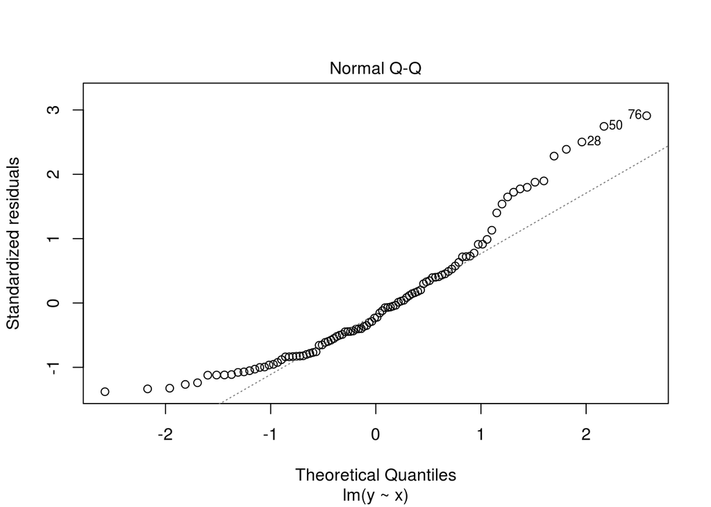

```r
plot(model.fit, which=2) # plot
```

With the non-normal model, the Normal Q-Q plot shows the tails of the residual going up, however the betas are largely non-affected and the MSE is essentially what it should be. Outside of looking at the Normal Q-Q plot, non-normality in the errors is largely not detectable as long as it has a mean of 0. If I had more time, I would standardize the amount of variance for each eps generating function so I can isolate the effects of non-normality from the effects of high variance.

## Question 3 (Heterogeneous Variances)

```
a.  Simulate errors from a variety of different relationships with X (e.g. eps = 2 * sqrt(x))
b.  Try simulations with a small sample size (e.g. 20), a medium sample size (e.g. n= 100), and a large sample size (e.g. n = 5000).
c.  For each simulation,
    i.  Predict y-hat at several different locations using a confidence interval.

    ii. Predict the beta coefficients for a linear model using a confidence interval.

    iii. Find the MSE (to estimate sigma^2-- does that even make sense here?)

    iv. Test to see whether the beta(s) are significant (t-tests)
```

```r
set.seed(5)

list = c(20,200,5000)
paste("///////////////", "eps sd = e^x","///////////////" )
```

```
## [1] "/////////////// eps sd = e^x ///////////////"
```

```r
print("")
```

```
## [1] ""
```

```r
for (n in list){
x <- runif(n, 0, 10)
eps <- rnorm(n, sd =  exp(1)^x)
y <- b0 + b1 * x + eps
#(hist(eps))
data_new <- as.data.frame(cbind(x,y))
colnames(data_new) <- c("x_var", "y")
fit1 <- lm(y~x_var, data = data_new)
summary(fit1)
print(paste("with sample size = ", n))
MSE <- anova(fit1)[2,3]
print(" i. Predict y-hat at several different locations using a confidence interval.")
print(predict(fit1,data.frame(x_var = c(1,5,2)), interval="confidence"))
print("ii. Predict the beta coefficients w/ confidence interval.")
summary(fit1)
print(confint(fit1))
print("iii. Find the MSE")
MSE <- anova(fit1)[2,3]
print(paste("MSE = ",MSE))
print("iv. Test to see whether the beta(s) are significant (t-tests)")
print(summary(fit1)$coefficients[,c(3,4)])
}
```

```
## [1] "with sample size =  20"
## [1] " i. Predict y-hat at several different locations using a confidence interval."
##          fit       lwr      upr
## 1  217.75759 -3153.560 3589.075
## 2 -367.03538 -2265.514 1531.443
## 3   71.55935 -2756.230 2899.349
## [1] "ii. Predict the beta coefficients w/ confidence interval."
##                  2.5 %    97.5 %
## (Intercept) -3596.8310 4324.7427
## x_var        -836.3666  543.9701
## [1] "iii. Find the MSE"
## [1] "MSE =  16328409.0930397"
## [1] "iv. Test to see whether the beta(s) are significant (t-tests)"
##                t value  Pr(>|t|)
## (Intercept)  0.1930533 0.8490788
## x_var       -0.4450380 0.6615978
## [1] "with sample size =  200"
## [1] " i. Predict y-hat at several different locations using a confidence interval."
##          fit       lwr       upr
## 1   98.69390 -802.9791 1000.3668
## 2 -127.82301 -669.3758  413.7298
## 3   42.06467 -723.5255  807.6548
## [1] "ii. Predict the beta coefficients w/ confidence interval."
##                 2.5 %    97.5 %
## (Intercept) -895.6453 1206.2916
## x_var       -236.3996  123.1411
## [1] "iii. Find the MSE"
## [1] "MSE =  15082904.5043609"
## [1] "iv. Test to see whether the beta(s) are significant (t-tests)"
##                t value  Pr(>|t|)
## (Intercept)  0.2914454 0.7710158
## x_var       -0.6212027 0.5351808
## [1] "with sample size =  5000"
## [1] " i. Predict y-hat at several different locations using a confidence interval."
##          fit        lwr      upr
## 1 -148.54862 -402.52422 105.4270
## 2  137.43635  -10.28737 285.1601
## 3  -77.05238 -291.47325 137.3685
## [1] "ii. Predict the beta coefficients w/ confidence interval."
##                  2.5 %    97.5 %
## (Intercept) -517.14564  77.05591
## x_var         20.32019 122.67230
## [1] "iii. Find the MSE"
## [1] "MSE =  28385213.0053021"
## [1] "iv. Test to see whether the beta(s) are significant (t-tests)"
##               t value    Pr(>|t|)
## (Intercept) -1.451980 0.146569843
## x_var        2.738859 0.006187134
```

```r
#with another error dist
paste("///////////////", "eps sd = x^3","///////////////" )
```

```
## [1] "/////////////// eps sd = x^3 ///////////////"
```

```r
print("")
```

```
## [1] ""
```

```r
set.seed(5)
list = c(20,200,5000)

for (n in list){
x <- runif(n, 0, 10)
eps <- rnorm(n, sd =  x^3)
y <- b0 + b1 * x + eps
#(hist(eps))
data_new <- as.data.frame(cbind(x,y))
colnames(data_new) <- c("x_var", "y")
fit1 <- lm(y~x_var, data = data_new)
summary(fit1)
print(paste("with sample size = ", n))
print(" i. Predict y-hat at several different locations using a confidence interval.")
print(predict(fit1,data.frame(x_var = c(1,5,2)), interval="confidence"))
print("ii. Predict the beta coefficients w/ confidence interval.")
summary(fit1)
print(confint(fit1))
print("iii. Find the MSE")
MSE <- anova(fit1)[2,3]
print(paste("MSE = ",MSE))
print("iv. Test to see whether the beta(s) are significant (t-tests)")
print(summary(fit1)$coefficients[,c(3,4)])
}
```

```
## [1] "with sample size =  20"
## [1] " i. Predict y-hat at several different locations using a confidence interval."
##         fit       lwr      upr
## 1  66.20250 -292.3664 424.7714
## 2 -45.89980 -247.8195 156.0199
## 3  38.17692 -262.5830 338.9369
## [1] "ii. Predict the beta coefficients w/ confidence interval."
##                2.5 %    97.5 %
## (Intercept) -327.036 515.49213
## x_var       -101.431  45.37982
## [1] "iii. Find the MSE"
## [1] "MSE =  184709.711644592"
## [1] "iv. Test to see whether the beta(s) are significant (t-tests)"
##                t value  Pr(>|t|)
## (Intercept)  0.4699329 0.6440461
## x_var       -0.8021148 0.4329495
## [1] "with sample size =  200"
## [1] " i. Predict y-hat at several different locations using a confidence interval."
##         fit       lwr       upr
## 1 23.412757 -58.95115 105.77666
## 2  2.971664 -46.49683  52.44016
## 3 18.302484 -51.63085  88.23582
## [1] "ii. Predict the beta coefficients w/ confidence interval."
##                 2.5 %    97.5 %
## (Intercept) -67.47837 124.52443
## x_var       -21.53151  11.31097
## [1] "iii. Find the MSE"
## [1] "MSE =  125852.191126867"
## [1] "iv. Test to see whether the beta(s) are significant (t-tests)"
##                t value  Pr(>|t|)
## (Intercept)  0.5859072 0.5586051
## x_var       -0.6136898 0.5401247
## [1] "with sample size =  5000"
## [1] " i. Predict y-hat at several different locations using a confidence interval."
##         fit        lwr      upr
## 1  1.948753 -17.071706 20.96921
## 2 23.896152  12.832990 34.95931
## 3  7.435603  -8.622568 23.49377
## [1] "ii. Predict the beta coefficients w/ confidence interval."
##                  2.5 %   97.5 %
## (Intercept) -25.788240 18.71205
## x_var         1.654229  9.31947
## [1] "iii. Find the MSE"
## [1] "MSE =  159202.614674892"
## [1] "iv. Test to see whether the beta(s) are significant (t-tests)"
##                t value    Pr(>|t|)
## (Intercept) -0.3117383 0.755252416
## x_var        2.8066001 0.005026121
```

```
d. Which of the above tasks were affected by the violation of assumptions?
```

-the MSE is VERY large. Clearly was affected -the confidence intervals for our y-hat predictions were all over the place. -In addition the beta coefficients were not close to the true values. The b1 coeficcient was significant when n = 5000 though. -In conclusion. All of the tasks were affected, but seemed to be not as bad the larger our sample size was.

```
e. After you have experimented with the effects of different model structures, true parameter values, and sample sizes, let's repeat the simulation but test yourself to see whether you can detect heteroskedacity.
```

```r
par(mfrow = c(3,1))
set.seed(5)
library(lmtest)
list = c(20,200,5000)
paste("///////////////", "eps sd = e^x","///////////////" )
```

```
## [1] "/////////////// eps sd = e^x ///////////////"
```

```r
print("")
```

```
## [1] ""
```

```
## [1] "with sample size =  20"
```

```
##
##  studentized Breusch-Pagan test
##
## data:  fit1
## BP = 6.9631, df = 1, p-value = 0.008321
##
## [1] "with sample size =  200"
```

```
##
##  studentized Breusch-Pagan test
##
## data:  fit1
## BP = 25.099, df = 1, p-value = 5.446e-07
##
## [1] "with sample size =  5000"
```

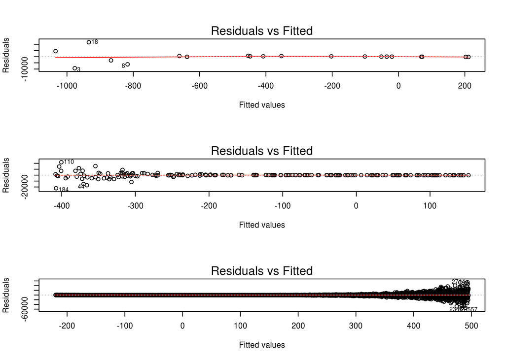

```
##
##  studentized Breusch-Pagan test
##
## data:  fit1
## BP = 417.22, df = 1, p-value < 2.2e-16
```

```r
for (n in list){
x <- runif(n, 0, 10)
eps <- rnorm(n, sd =  exp(1)^x)
y <- b0 + b1 * x + eps
#(hist(eps))
data_new <- as.data.frame(cbind(x,y))
colnames(data_new) <- c("x_var", "y")
fit1 <- lm(y~x_var, data = data_new)
summary(fit1)
print(paste("with sample size = ", n))
#informal
plot(fit1, which = 1)

#formal test
print(bptest(fit1))
}
```

```r
#with another error dist
paste("///////////////", "eps sd = x^3","///////////////" )
```

```
## [1] "/////////////// eps sd = x^3 ///////////////"
```

```r
print("")
```

```
## [1] ""
```

```
## [1] "with sample size =  20"
```

```
##
##  studentized Breusch-Pagan test
##
## data:  fit1
## BP = 6.1803, df = 1, p-value = 0.01292
##
## [1] "with sample size =  200"
```

```
##
##  studentized Breusch-Pagan test
##
## data:  fit1
## BP = 30.998, df = 1, p-value = 2.582e-08
##
## [1] "with sample size =  5000"
```

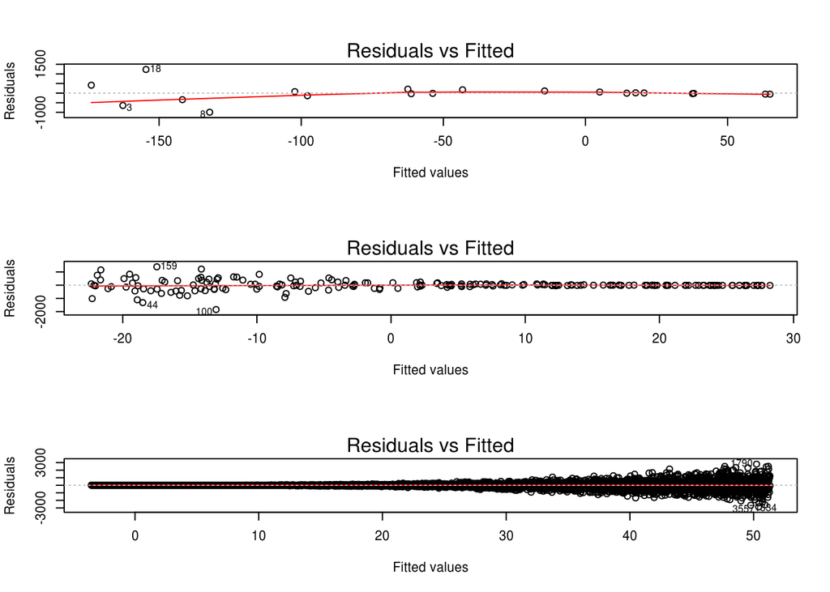

```
##
##  studentized Breusch-Pagan test
##
## data:  fit1
## BP = 816.09, df = 1, p-value < 2.2e-16
```

```r
set.seed(5)
list = c(20,200,5000)
par(mfrow = c(3,1))
for (n in list){
x <- runif(n, 0, 10)
eps <- rnorm(n, sd =  x^3)
y <- b0 + b1 * x + eps
#(hist(eps))
data_new <- as.data.frame(cbind(x,y))
colnames(data_new) <- c("x_var", "y")
fit1 <- lm(y~x_var, data = data_new)
summary(fit1)
print(paste("with sample size = ", n))
#informal
plot(fit1, which = 1)

#formal test
print(bptest(fit1))
}
```

-cleary there is non-constant variance present. (resid vs fitted plot “fans”) -really small p-value for all, so we reject the null and determine that there is significant heteroskedacity.

```
    i. Have R randomly choose whether to simulate errors with constant or non-constant variance


    ii. Simulate data accordingly and display informal/ formal diagnostics as appropriate.

    iii. Based on the diagnostics, predict whether the problem areas you mentioned in part d will be affected or not. (Note: You are not predicting whether the assumptions are violated-- just whether they are violated to such an extent that your ability to use the model is compromised)
```

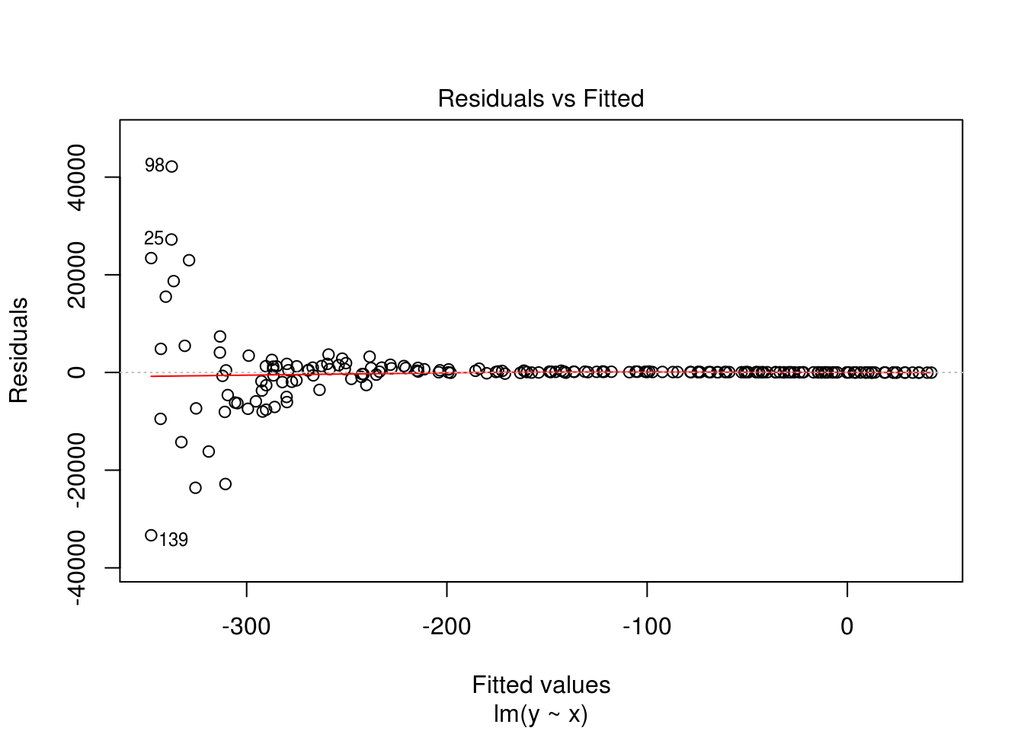

```
## [1] "pvalue is below .05. Non constant variance present"
```

```r
yes_func <- function (n) {
  #n<- 200
  x <- runif(n, 0, 10)
  eps <- rnorm(n, sd =  exp(1)^x)
  y <- b0 + b1 * x + eps
  fit <- lm(y~x)
  #informal
  plot(fit, which = 1)
  #formal
  x <- bptest(fit)[4]
  ifelse(x < .05, return("pvalue is below .05. Non constant variance present"), return("everything is fine!"))

}

no_func <- function (n) {
  #n<- 200
  x <- runif(n, 0, 10)
  eps <- rnorm(n, sd =  x)
  y <- b0 + b1 * x + eps
  fit <- lm(y~x)
  #informal
  plot(fit, which = 1)
  #formal
  x <- bptest(fit)[4]
  ifelse(x < .05, return("We predict model is comprimised"), return("everything is probably ok"))
}

ifelse(runif(1,0,1) > .5,yes_func(200), no_func(200) )
```

## Question 4 (Correlated Errors)

```
a.  Simulate errors from a variety of different correlation structures.
b.  Try simulations with a small sample size (e.g. 20), a medium sample size (e.g. n= 100), and a large sample size (e.g. n = 5000).
c.  For each simulation,
    i.  Predict y-hat at several different locations using a confidence interval.
    ii. Predict the beta coefficients for a linear model using a confidence interval.
    iii. Find the MSE (to estimate sigma^2)
    iv. Test to see whether the beta(s) are significant (t-tests)
d. Which of the above tasks were affected by the violation of assumptions?
e. After you have experimented with the effects of different model structures, true parameter values, and sample sizes, let's repeat the simulation but test yourself to see whether you can detect correlated errors.
    i. Have R randomly choose whether to simulate data with correlated or uncorrelated errors.
    ii. Simulate data accordingly and display informal/ formal diagnostics as appropriate.
    iii. Based on the diagnostics, predict whether the problem areas you mentioned in part d will be affected or not. (Note: You are not predicting whether the assumptions are violated-- just whether they are violated to such an extent that your ability to use the model is compromised)
```

```r
set.seed(1234)
#values of true betas and sigma
b0 <- 10
b1 <- 10
sigma <- 2

simulations <- function(n,rho){
#initialize percentages
bad_yhat = 0
beta1p = 0
beta0p = 0
msq = 0
pvalb0 = 0
pvalb1 = 0

for (i in 1:100){
  x <- runif(n, 0, 10)
  newx <- runif(20,0,10)
  eps <- rep(0, n)
  e.ind <- rnorm(n, mean = 0, sd = (sigma / sqrt(1-rho^2)))
  eps[1] <- e.ind[1]
  for (i in 2:n) {
    eps[i] <- rho * eps[i-1] + e.ind[i]
  }
  y <- b0 + b1 * x + eps

  lm.err <- lm(y~x)

  testmodel <- b0 + b1 * newx


  y_hat_ci <- predict(lm.err, newdata = data.frame(x = I(newx)), interval = "confidence")
  bad_yhat <- 20 - sum((testmodel >= y_hat_ci[,2]) & (testmodel <= y_hat_ci[,3]))


  beta1ci <- confint(lm.err, "x",level=.95 )
  if(b1 > beta1ci[1] & b1 < beta1ci[2]){
    beta1p <- beta1p + 1
  }
  beta0ci <- confint(lm.err,"(Intercept)",level=.95)
  if(b1 > beta0ci[1] & b1 < beta0ci[2]){
    beta0p <- beta0p + 1
  }
  #take average of MSE
  anov <- anova(lm.err)
  msq <- msq + anov$`Mean Sq`[2]

  #check if b0 is significant
  summ <- summary(lm.err)$coefficients[,4]
  if (summ[1]< .05){
    pvalb0 <- pvalb0 + 1
  }

  #check if b1 is significant
  if (summ[2] < .05){
    pvalb1 <- pvalb1 + 1
  }


}

#return percentage of simulations that captured true paramater in confidence interval
results <- data.frame(bad_yhat/100,
                      beta1p/100,
                      beta0p/100,
                      msq/100,
                      pvalb0/100,
                      pvalb1/100)

return(results)

}

#Samples with rho = .3
small_samp1 = simulations(20, .3)
med_samp1=simulations(100, .3)
lrg_samp1=simulations(5000, .3)
small_rho <- matrix(c(small_samp1, med_samp1,lrg_samp1),byrow=T, nrow=3)
colnames(small_rho) <-c("bad_yhat","beta1","beta0","avg mse","pvalb0","pvalb1")
rownames(small_rho) <-c("small sample", "medium sample", "large sample")
small_rho
```

```
##               bad_yhat beta1 beta0 avg mse  pvalb0 pvalb1
## small sample  0        0.93  0.92  4.795313 1      1
## medium sample 0        0.95  0.94  4.749659 1      1
## large sample  0        0.94  0.88  4.824775 1      1
```

```r
#samples with rho=.9
small_samp2 = simulations(20, .9)
med_samp2=simulations(100, .9)
lrg_samp2=simulations(5000, .9)
large_rho <- matrix(c(small_samp2, med_samp2,lrg_samp2),byrow=T, nrow=3)
colnames(large_rho) <-c("bad_yhat","beta1","beta0","avg mse","pvalb0","pvalb1")
rownames(large_rho) <-c("small sample", "medium sample", "large sample")
large_rho
```

```
##               bad_yhat beta1 beta0 avg mse  pvalb0 pvalb1
## small sample  0.19     0.96  0.57  42.38226 0.74   1
## medium sample 0.02     0.98  0.6   87.22251 0.94   1
## large sample  0.2      0.93  0.52  110.1356 1      1
```

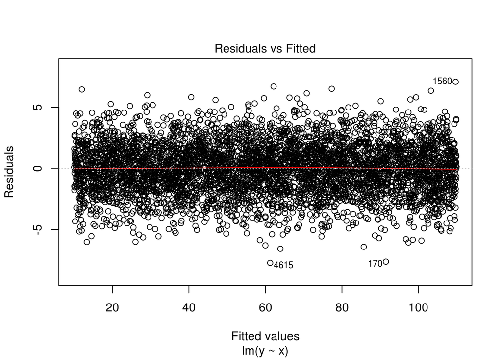

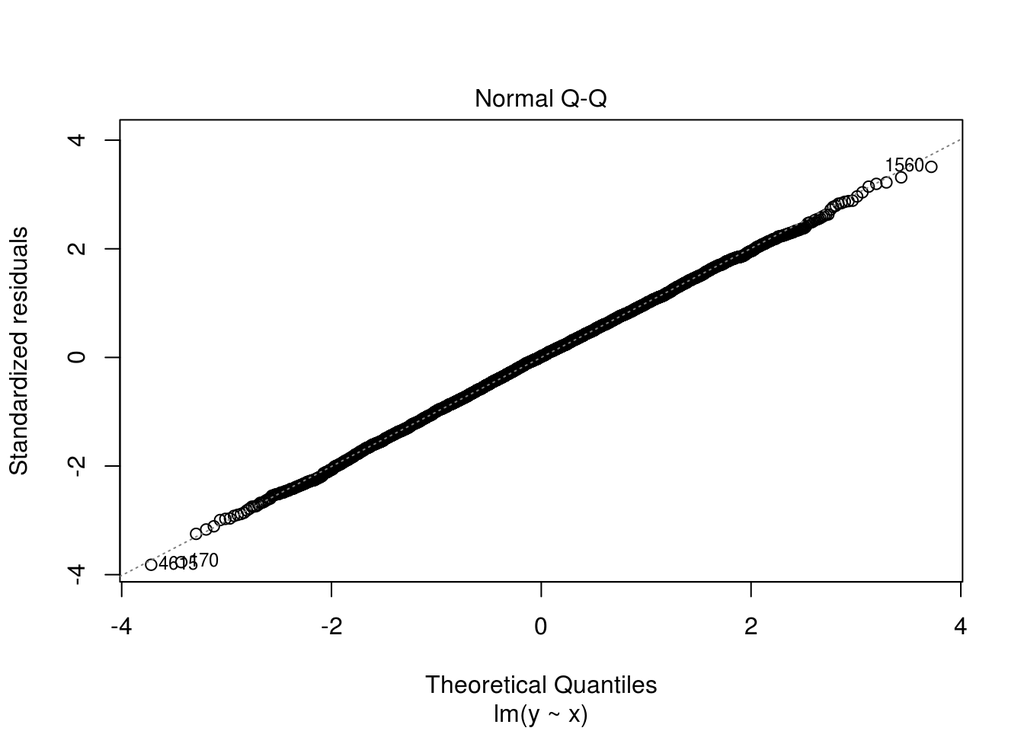

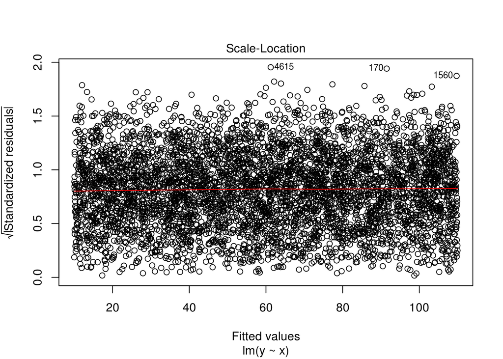

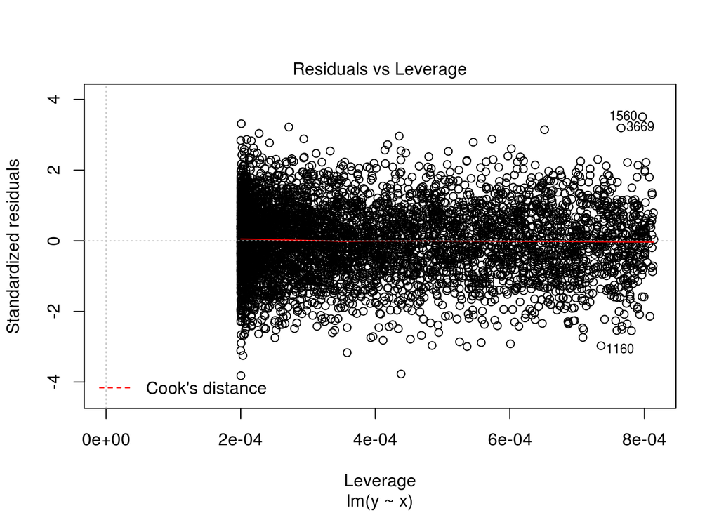

```r
set.seed(12)
rho_vec <- c(0, .8)
#choose random value of rho
rho <- sample(rho_vec,1)


  x <- runif(n, 0, 10)
  newx <- runif(n,0,10)
  eps <- rep(0, n)
  e.ind <- rnorm(n, mean = 0, sd = (sigma / sqrt(1-rho^2)))
  eps[1] <- e.ind[1]
  for (i in 2:n) {
    eps[i] <- rho * eps[i-1] + e.ind[i]
  }
  y <- b0 + b1 * x + eps

  lm.random <- lm(y~x)

  plot(lm.random)
```

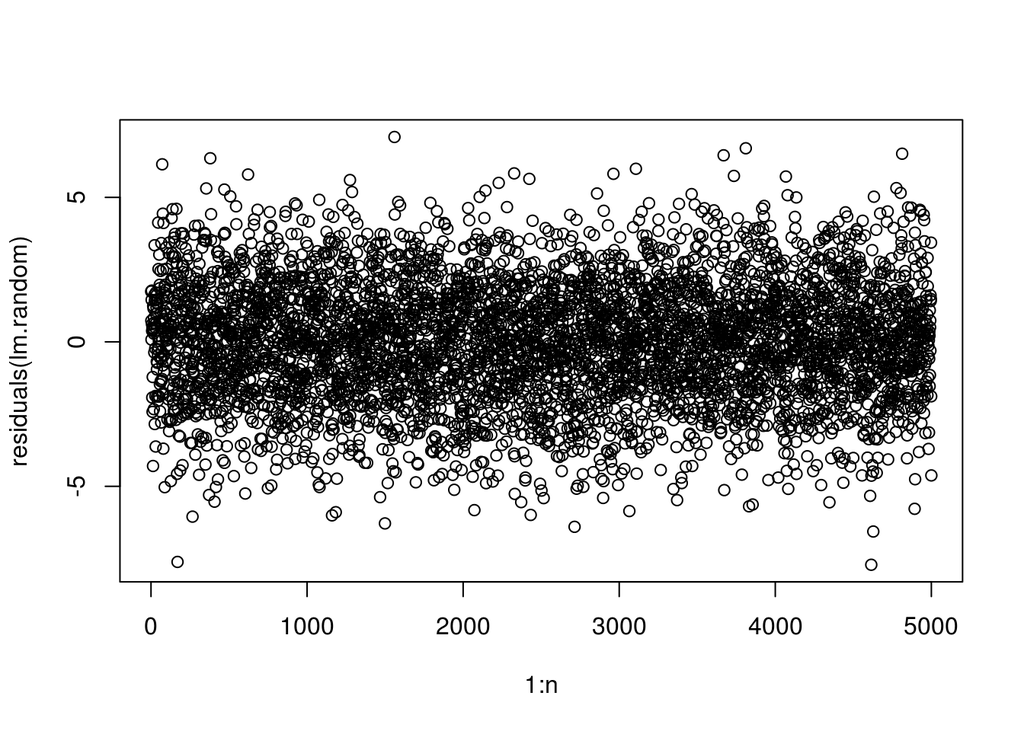

```r
  plot(1:n, residuals(lm.random))
```

Given the plot of the residuals, it appears that the error terms are not correlated so problem areas in part d will not be affected.

## Question 5 (Multicollinearity)

# a. Simulate predictors that are correlated with a variety of different correlation structures

```r
n = 5000
a = rnorm(n)
b = 1 + a
c = 2 + rnorm(n) + 2 * a
summary(lm(c ~ b + a))
```

```
##
## Call:
## lm(formula = c ~ b + a)
##
## Residuals:
##     Min      1Q  Median      3Q     Max
## -4.4268 -0.6726 -0.0107  0.6619  3.7679
##
## Coefficients: (1 not defined because of singularities)
##              Estimate Std. Error t value Pr(>|t|)
## (Intercept) -0.004148   0.020045  -0.207    0.836
## b            2.019572   0.014176 142.469   <2e-16 ***
## a                  NA         NA      NA       NA
## ---
## Signif. codes:  0 '***' 0.001 '**' 0.01 '*' 0.05 '.' 0.1 ' ' 1
##
## Residual standard error: 0.9911 on 4998 degrees of freedom
## Multiple R-squared:  0.8024, Adjusted R-squared:  0.8024
## F-statistic: 2.03e+04 on 1 and 4998 DF,  p-value: < 2.2e-16
```

```r
n = 5000
a = rnorm(n)
b = 2 * a
c = 2 + rnorm(n) + 2 * a
summary(lm(c ~ b + a))
```

```
##
## Call:
## lm(formula = c ~ b + a)
##
## Residuals:
##     Min      1Q  Median      3Q     Max
## -4.2381 -0.6790 -0.0091  0.6694  3.6656
##
## Coefficients: (1 not defined because of singularities)
##             Estimate Std. Error t value Pr(>|t|)
## (Intercept) 2.014131   0.014168   142.2   <2e-16 ***
## b           1.007947   0.007068   142.6   <2e-16 ***
## a                 NA         NA      NA       NA
## ---
## Signif. codes:  0 '***' 0.001 '**' 0.01 '*' 0.05 '.' 0.1 ' ' 1
##
## Residual standard error: 1.001 on 4998 degrees of freedom
## Multiple R-squared:  0.8027, Adjusted R-squared:  0.8027
## F-statistic: 2.034e+04 on 1 and 4998 DF,  p-value: < 2.2e-16
```

# b. Try simulations with a small sample size (e.g. 20), a medium sample size (e.g. n= 100), and a large sample size (e.g. n = 5000).

```r
n = 20
a = rnorm(n)
b = 1 + a
c = 2 + rnorm(n) + 2 * a
model_20 <- lm(c ~ b + a)
summary(model_20)
```

```
##
## Call:
## lm(formula = c ~ b + a)
##
## Residuals:
##     Min      1Q  Median      3Q     Max
## -2.0999 -0.9939  0.2388  0.9534  1.6732
##
## Coefficients: (1 not defined because of singularities)
##             Estimate Std. Error t value Pr(>|t|)
## (Intercept)  -0.1534     0.3394  -0.452    0.657
## b             2.0613     0.2020  10.205 6.52e-09 ***
## a                 NA         NA      NA       NA
## ---
## Signif. codes:  0 '***' 0.001 '**' 0.01 '*' 0.05 '.' 0.1 ' ' 1
##
## Residual standard error: 1.22 on 18 degrees of freedom
## Multiple R-squared:  0.8526, Adjusted R-squared:  0.8445
## F-statistic: 104.2 on 1 and 18 DF,  p-value: 6.525e-09
```

```r
n = 100
a = rnorm(n)
b = 1 + a
c = 2 + rnorm(n) + 2 * a
model_100 <- lm(c ~ b + a)
summary(model_100)
```

```
##
## Call:
## lm(formula = c ~ b + a)
##
## Residuals:
##     Min      1Q  Median      3Q     Max
## -3.6869 -0.6647  0.0450  0.8239  2.5706
##
## Coefficients: (1 not defined because of singularities)
##             Estimate Std. Error t value Pr(>|t|)
## (Intercept)   0.2130     0.1757   1.212    0.228
## b             1.9325     0.1149  16.814   <2e-16 ***
## a                 NA         NA      NA       NA
## ---
## Signif. codes:  0 '***' 0.001 '**' 0.01 '*' 0.05 '.' 0.1 ' ' 1
##
## Residual standard error: 1.146 on 98 degrees of freedom
## Multiple R-squared:  0.7426, Adjusted R-squared:   0.74
## F-statistic: 282.7 on 1 and 98 DF,  p-value: < 2.2e-16
```

```r
n = 5000
a = rnorm(n)
b = 1 + a
c = 2 + rnorm(n) + 2 * a
model_5000 <- lm(c ~ b + a)
summary(model_5000)
```

```
##
## Call:
## lm(formula = c ~ b + a)
##
## Residuals:
##     Min      1Q  Median      3Q     Max
## -3.2929 -0.6868  0.0044  0.6712  3.4079
##
## Coefficients: (1 not defined because of singularities)
##             Estimate Std. Error t value Pr(>|t|)
## (Intercept) -0.01254    0.01996  -0.628     0.53
## b            2.01529    0.01415 142.458   <2e-16 ***
## a                 NA         NA      NA       NA
## ---
## Signif. codes:  0 '***' 0.001 '**' 0.01 '*' 0.05 '.' 0.1 ' ' 1
##
## Residual standard error: 0.9933 on 4998 degrees of freedom
## Multiple R-squared:  0.8024, Adjusted R-squared:  0.8024
## F-statistic: 2.029e+04 on 1 and 4998 DF,  p-value: < 2.2e-16
```

# c. For each simulation,

## i. Predict y-hat at several different locations using a confidence interval.

```r
prediction_points <- matrix(c(-2,  -3,
                              -0.5, 2,
                               0,   0,
                               4,   5), ncol=2)
prediction_points <- data.frame(prediction_points)
colnames(prediction_points) <- c("a", "b")
predict.lm(model_20, newdata = prediction_points, interval = "prediction")
```

```
##          fit       lwr       upr
## 1 -0.1533596 -2.813576  2.506857
## 2 -0.1533596 -2.813576  2.506857
## 3  8.0918256  5.173419 11.010232
## 4 10.1531219  7.026220 13.280024
```

```r
prediction_points <- matrix(c(-2,  -3,
                              -0.5, 2,
                               0,   0,
                               4,   5), ncol=2)
prediction_points <- data.frame(prediction_points)
colnames(prediction_points) <- c("a", "b")
predict.lm(model_100, newdata = prediction_points, interval = "prediction")
```

```
##         fit       lwr       upr
## 1 0.2129741 -2.086833  2.512781
## 2 0.2129741 -2.086833  2.512781
## 3 7.9431402  5.568455 10.317825
## 4 9.8756818  7.428900 12.322463
```

```r
prediction_points <- matrix(c(-2,  -3,
                              -0.5, 2,
                               0,   0,
                               4,   5), ncol=2)
prediction_points <- data.frame(prediction_points)
colnames(prediction_points) <- c("a", "b")
predict.lm(model_5000, newdata = prediction_points, interval = "prediction")
```

```
##           fit       lwr       upr
## 1 -0.01253971 -1.960178  1.935099
## 2 -0.01253971 -1.960178  1.935099
## 3  8.04860765  6.099394  9.997821
## 4 10.06389449  8.113301 12.014488
```

## ii. Predict the beta coefficients for a linear model using a confidence interval.

```r
confint(model_20)
```

```
##                  2.5 %    97.5 %
## (Intercept) -0.8664696 0.5597503
## b            1.6369535 2.4856391
## a                   NA        NA
```

```r
confint(model_100)
```

```
##                  2.5 %    97.5 %
## (Intercept) -0.1356658 0.5616139
## b            1.7044595 2.1606236
## a                   NA        NA
```

```r
confint(model_5000)
```

```
##                   2.5 %   97.5 %
## (Intercept) -0.05166642 0.026587
## b            1.98755348 2.043020
## a                    NA       NA
```

## iii. Find the MSE (to estimate sigmaˆ2)

```r
calculate_mse <- function(model){ return (c(crossprod(model$residuals)) / length(model$residuals))}
calculate_mse(model_20)
```

```
## [1] 1.339278
```

```r
calculate_mse(model_100)
```

```
## [1] 1.285949
```

```r
calculate_mse(model_5000)
```

```
## [1] 0.9861908
```

## iv. Test to see whether the beta(s) are significant (t-tests)

```r
t_test_on_lm <- function(model){
  return(1 -
    pt(coef(summary(model))[,3],
     df = summary(model)$df[2])
  )

}
t_test_on_lm(model_20)
```

```
##  (Intercept)            b
## 6.716018e-01 3.262345e-09
```

```r
t_test_on_lm(model_100)
```

```
## (Intercept)           b
##   0.1141648   0.0000000
```

```r
t_test_on_lm(model_5000)
```

```
## (Intercept)           b
##    0.735082    0.000000
```

# d. Which of the above tasks were affected by the violation of assumptions?

The betas and the MSE can vary substantially when predictor variables are highly correlated. Additionally, while predicting y-hat seemed to work out in my case, it may not be sensible to interpret predictions where correlated variables have widely different values.

# e. After you have experimented with the effects of different model structures, true parameter values, and sample sizes, let’s repeat the simulation but test yourself to see whether you can detect collinearity.

## i. Have R randomly choose whether to simulate data with correlated or uncorrelated predictor variables (X).

```r
simulate_data <- function (is_correlated) {
  n <- 20
  b0 <- 10
  b1 <- 3
  b2 <- 7
  sigma <- 2
  x1 <- runif(n, 0, 10)
  x2 <- is_correlated * x1 + rnorm(n)
  cor(x1, x2)
  eps <- rnorm(n = n, sd = sigma)
  y <- b0 + b1 * x1 + b2 * x2 + eps
  return (data.frame(y, x1, x2))
  }
```

## ii. Simulate data accordingly and display informal/ formal diagnostics as appropriate.

```r
run_regression <- function(data){return(lm(y ~ x1 + x2, data = data))}

print("first")
```

```
## [1] "first"
```

```r
first_model <- run_regression(simulate_data(TRUE))
first_model$coefficients
```

```
## (Intercept)          x1          x2
##    9.989601    3.358247    6.579198
```

```r
confint(first_model)
```

```
##                2.5 %    97.5 %
## (Intercept) 7.207314 12.771888
## x1          2.251137  4.465356
## x2          5.458416  7.699981
```

```r
print("")
```

```
## [1] ""
```

```r
print("second")
```

```
## [1] "second"
```

```r
second_model <- run_regression(simulate_data(FALSE))
second_model$coefficients
```

```
## (Intercept)          x1          x2
##   10.402647    2.846748    7.218963
```

```r
confint(second_model)
```

```
##                2.5 %    97.5 %
## (Intercept) 8.098163 12.707131
## x1          2.433279  3.260217
## x2          6.205081  8.232845
```

```r
print("")
```

```
## [1] ""
```

```r
print("third")
```

```
## [1] "third"
```

```r
third_model <- run_regression(simulate_data(TRUE))
third_model$coefficients
```

```
## (Intercept)          x1          x2
##    9.484103    2.789600    7.332530
```

```r
confint(third_model)
```

```
##                2.5 %    97.5 %
## (Intercept) 7.178804 11.789401
## x1          1.265393  4.313806
## x2          6.043732  8.621328
```

```r
print("")
```

```
## [1] ""
```

```r
print("fourth")
```

```
## [1] "fourth"
```

```r
fourth_model <- run_regression(simulate_data(FALSE))
fourth_model$coefficients
```

```
## (Intercept)          x1          x2
##    9.761414    3.056835    6.376564
```

```r
confint(fourth_model)
```

```
##                2.5 %    97.5 %
## (Intercept) 7.709166 11.813661
## x1          2.687860  3.425809
## x2          5.055825  7.697303
```

```r
calculate_mse(first_model)
```

```
## [1] 5.306501
```

```r
calculate_mse(second_model)
```

```
## [1] 3.959687
```

```r
calculate_mse(third_model)
```

```
## [1] 4.707493
```

```r
calculate_mse(fourth_model)
```

```
## [1] 4.671093
```

## iii. Based on the diagnostics, predict whether the problem areas you mentioned in part d will be affected or not. (Note: You are not predicting whether the assumptions are violated– just whether they are violated to such an extent that your ability to use the model is compromised)

The coefficients do not appear to exhibit much variability, and neither does the MSE. It does not appear that the ability for me to use my model is substantially compromised.

6. Put it all together: Combine the code from the previous 5 parts. Have R randomly choose whether to generate data that violates one (or more) of the assumptions, or whether all the assumptions are valid. Show appropriate diagnostics and test yourself to see if you can predict whether there are problem areas or not. Repeat the simulation several times and record your accuracy at detecting the different problem areas.